# Project_1

Suyog Dharmadhikari

2022-09-09

The goal of the project is to write functions that will manipulate and process data sets. It will have a generic function that will automatically plot the returned data.

# Data Processing

1. The given csv file has 42 variables which are no useful for our analysis. Hence we only select Area_name as area_name, STCOU, and columns ending with “D” using select() function.

```r
censusData <- rawData %>%
  select(Area_name, STCOU, ends_with("D")) %>%
  rename("area_name" = Area_name)
censusData
```

```
## # A tibble: 3,198 × 12
##    area_…¹ STCOU EDU01…² EDU01…³ EDU01…⁴ EDU01…⁵ EDU01…⁶ EDU01…⁷ EDU01…⁸ EDU01…⁹
##    <chr>   <chr>   <dbl>   <dbl>   <dbl>   <dbl>   <dbl>   <dbl>   <dbl>   <dbl>
##  1 UNITED… 00000  4.00e7  4.00e7  4.03e7  4.07e7  4.14e7  4.21e7  4.27e7  4.34e7
##  2 ALABAMA 01000  7.34e5  7.28e5  7.30e5  7.28e5  7.26e5  7.26e5  7.28e5  7.31e5
##  3 Autaug… 01001  6.83e3  6.9 e3  6.92e3  6.85e3  7.01e3  7.14e3  7.15e3  7.38e3
##  4 Baldwi… 01003  1.64e4  1.65e4  1.68e4  1.71e4  1.75e4  1.80e4  1.87e4  1.94e4
##  5 Barbou… 01005  5.07e3  5.10e3  5.07e3  5.16e3  5.17e3  5.25e3  5.14e3  5.11e3
##  6 Bibb, … 01007  3.56e3  3.51e3  3.57e3  3.62e3  3.65e3  3.56e3  3.56e3  3.55e3
##  7 Blount… 01009  7.32e3  7.22e3  7.20e3  7.21e3  7.16e3  7.15e3  7.21e3  7.3 e3
##  8 Bulloc… 01011  2.01e3  1.98e3  1.98e3  1.98e3  1.98e3  2.02e3  2.01e3  2.01e3
##  9 Butler… 01013  4.64e3  4.58e3  4.61e3  4.59e3  4.54e3  4.48e3  4.44e3  4.35e3
## 10 Calhou… 01015  2.09e4  2.09e4  2.09e4  2.08e4  2.08e4  2.05e4  2.05e4  2.01e4
## # … with 3,188 more rows, 2 more variables: EDU010195D <dbl>, EDU010196D <dbl>,
## #   and abbreviated variable names ¹area_name, ²EDU010187D, ³EDU010188D,
## #   ⁴EDU010189D, ⁵EDU010190D, ⁶EDU010191D, ⁷EDU010192D, ⁸EDU010193D,
## #   ⁹EDU010194D
```

2. Now we convert the dataset or tibble into long format such that each area_name will have only one enrollment in each row.This will helps us in the future for plotting and analysis.

```r
longCensusData <- censusData %>%
  pivot_longer(cols = 3:12, names_to = "item_ID", values_to = "US_total")
longCensusData
```

```
## # A tibble: 31,980 × 4
##    area_name     STCOU item_ID    US_total
##    <chr>         <chr> <chr>         <dbl>
##  1 UNITED STATES 00000 EDU010187D 40024299
##  2 UNITED STATES 00000 EDU010188D 39967624
##  3 UNITED STATES 00000 EDU010189D 40317775
##  4 UNITED STATES 00000 EDU010190D 40737600
##  5 UNITED STATES 00000 EDU010191D 41385442
##  6 UNITED STATES 00000 EDU010192D 42088151
##  7 UNITED STATES 00000 EDU010193D 42724710
##  8 UNITED STATES 00000 EDU010194D 43369917
##  9 UNITED STATES 00000 EDU010195D 43993459
## 10 UNITED STATES 00000 EDU010196D 44715737
## # … with 31,970 more rows
```

3. The given tibble gives no clear idea about year and measurement ID’s. Hence we use Substr() to create substring of the given item_ID and as.date() was used to create the year column from the substring, which in turn will help us in our future analysis.

```r
longCensusData$year = as.Date(substr(longCensusData$item_ID,8,9),"%y")
longCensusData$year <- as.numeric(format(longCensusData$year,"%Y"))
longCensusData$measurement = substr(longCensusData$item_ID,1,7)
longCensusData
```

```
## # A tibble: 31,980 × 6
##    area_name     STCOU item_ID    US_total  year measurement
##    <chr>         <chr> <chr>         <dbl> <dbl> <chr>
##  1 UNITED STATES 00000 EDU010187D 40024299  1987 EDU0101
##  2 UNITED STATES 00000 EDU010188D 39967624  1988 EDU0101
##  3 UNITED STATES 00000 EDU010189D 40317775  1989 EDU0101
##  4 UNITED STATES 00000 EDU010190D 40737600  1990 EDU0101
##  5 UNITED STATES 00000 EDU010191D 41385442  1991 EDU0101
##  6 UNITED STATES 00000 EDU010192D 42088151  1992 EDU0101
##  7 UNITED STATES 00000 EDU010193D 42724710  1993 EDU0101
##  8 UNITED STATES 00000 EDU010194D 43369917  1994 EDU0101
##  9 UNITED STATES 00000 EDU010195D 43993459  1995 EDU0101
## 10 UNITED STATES 00000 EDU010196D 44715737  1996 EDU0101
## # … with 31,970 more rows
```

4. The given data set has mix of county and state data, it is important to divide this data into state data and county data to study the trend of census based on state and county.The below code involves dividing the tibble into non_county_data and county_data using grep() and change the class type of the tibbles.

```r
county <- grep(pattern = ", \\w\\w", longCensusData$area_name)
county_data <- longCensusData[county,]
non_county_data <- longCensusData[-county,]
class(county_data) <- c("county", class(county_data))
class(non_county_data) <- c("state", class(non_county_data))
county_data
```

```
## # A tibble: 31,450 × 6
##    area_name   STCOU item_ID    US_total  year measurement
##    <chr>       <chr> <chr>         <dbl> <dbl> <chr>
##  1 Autauga, AL 01001 EDU010187D     6829  1987 EDU0101
##  2 Autauga, AL 01001 EDU010188D     6900  1988 EDU0101
##  3 Autauga, AL 01001 EDU010189D     6920  1989 EDU0101
##  4 Autauga, AL 01001 EDU010190D     6847  1990 EDU0101
##  5 Autauga, AL 01001 EDU010191D     7008  1991 EDU0101
##  6 Autauga, AL 01001 EDU010192D     7137  1992 EDU0101
##  7 Autauga, AL 01001 EDU010193D     7152  1993 EDU0101
##  8 Autauga, AL 01001 EDU010194D     7381  1994 EDU0101
##  9 Autauga, AL 01001 EDU010195D     7568  1995 EDU0101
## 10 Autauga, AL 01001 EDU010196D     7834  1996 EDU0101
## # … with 31,440 more rows
```

```r
class(county_data)
```

```
## [1] "county"     "tbl_df"     "tbl"        "data.frame"
```

```r
non_county_data
```

```
## # A tibble: 530 × 6
##    area_name     STCOU item_ID    US_total  year measurement
##    <chr>         <chr> <chr>         <dbl> <dbl> <chr>
##  1 UNITED STATES 00000 EDU010187D 40024299  1987 EDU0101
##  2 UNITED STATES 00000 EDU010188D 39967624  1988 EDU0101
##  3 UNITED STATES 00000 EDU010189D 40317775  1989 EDU0101
##  4 UNITED STATES 00000 EDU010190D 40737600  1990 EDU0101
##  5 UNITED STATES 00000 EDU010191D 41385442  1991 EDU0101
##  6 UNITED STATES 00000 EDU010192D 42088151  1992 EDU0101
##  7 UNITED STATES 00000 EDU010193D 42724710  1993 EDU0101
##  8 UNITED STATES 00000 EDU010194D 43369917  1994 EDU0101
##  9 UNITED STATES 00000 EDU010195D 43993459  1995 EDU0101
## 10 UNITED STATES 00000 EDU010196D 44715737  1996 EDU0101
## # … with 520 more rows
```

```r
class(non_county_data)
```

```
## [1] "state"      "tbl_df"     "tbl"        "data.frame"
```

5.The given tibble has a variable which has information of county and state. In order to determine the state of every county we added a new variable that describes the state of all the county’s using str_sub()

```r
county_data$state <- str_sub(county_data$area_name,-2)
county_data
```

```
## # A tibble: 31,450 × 7
##    area_name   STCOU item_ID    US_total  year measurement state
##    <chr>       <chr> <chr>         <dbl> <dbl> <chr>       <chr>
##  1 Autauga, AL 01001 EDU010187D     6829  1987 EDU0101     AL
##  2 Autauga, AL 01001 EDU010188D     6900  1988 EDU0101     AL
##  3 Autauga, AL 01001 EDU010189D     6920  1989 EDU0101     AL
##  4 Autauga, AL 01001 EDU010190D     6847  1990 EDU0101     AL
##  5 Autauga, AL 01001 EDU010191D     7008  1991 EDU0101     AL
##  6 Autauga, AL 01001 EDU010192D     7137  1992 EDU0101     AL
##  7 Autauga, AL 01001 EDU010193D     7152  1993 EDU0101     AL
##  8 Autauga, AL 01001 EDU010194D     7381  1994 EDU0101     AL
##  9 Autauga, AL 01001 EDU010195D     7568  1995 EDU0101     AL
## 10 Autauga, AL 01001 EDU010196D     7834  1996 EDU0101     AL
## # … with 31,440 more rows
```

6. In USA every state is incorporated with a division , to show that we have added a new variable to non_county/state data that shows the division corresponding to a particular state.Firstly we have created vectors for each division and then we can search each value of column area_name and determine its division

```r
New_England <- c("Connecticut", "Maine", "Massachusetts", "New Hampshire", "Rhode Island", "Vermont")

Mid_Atlantic <- c("New Jersey", "New York", "Pennsylvania")

East_North_Central <- c("Illinois", "Indiana", "Michigan", "Ohio","Wisconsin")

West_North_Central <- c("Iowa", "Kansas", "Minnesota", "Missouri", "Nebraska", "North Dakota","South Dakota")

South_Atlantic <- c("Delaware", "Florida", "Georgia", "Maryland", "North Carolina", "South Carolina", "Virginia", "DISTRICT OF COLUMBIA", "West Virginia")

East_South_Central <- c("Alabama", "Kentucky", "Mississippi", "Tennessee")

West_South_Central <- c("Arkansas", "Louisiana", "Oklahoma", "Texas")

Pacific <- c("Alaska", "California", "Hawaii", "Oregon", "Washington")

Mountain <- c("Arizona", "Colorado", "Idaho", "Montana", "Nevada", "New Mexico", "Utah", "Wyoming")

non_county_data <- non_county_data %>%
  mutate(division = if_else(tolower(non_county_data$area_name) %in% tolower(New_England),"New England",
                    if_else(tolower(non_county_data$area_name) %in% tolower(Mid_Atlantic),"Mid Atlantic",
                    if_else(tolower(non_county_data$area_name) %in% tolower(East_North_Central),"East North Central",
                    if_else(tolower(non_county_data$area_name) %in% tolower(West_North_Central),"West North Central",
                    if_else(tolower(non_county_data$area_name) %in% tolower(South_Atlantic),"South Atlantic",
                    if_else(tolower(non_county_data$area_name) %in% tolower(East_South_Central),"East South Central",
                    if_else(tolower(non_county_data$area_name) %in% tolower(West_South_Central),"West South Central",
                    if_else(tolower(non_county_data$area_name) %in% tolower(Pacific),"Pacific",
                    if_else(tolower(non_county_data$area_name) %in% tolower(Mountain),"Mountain", "ERROR" ))))))))))
non_county_data
```

```
## # A tibble: 530 × 7
##    area_name     STCOU item_ID    US_total  year measurement division
##    <chr>         <chr> <chr>         <dbl> <dbl> <chr>       <chr>
##  1 UNITED STATES 00000 EDU010187D 40024299  1987 EDU0101     ERROR
##  2 UNITED STATES 00000 EDU010188D 39967624  1988 EDU0101     ERROR
##  3 UNITED STATES 00000 EDU010189D 40317775  1989 EDU0101     ERROR
##  4 UNITED STATES 00000 EDU010190D 40737600  1990 EDU0101     ERROR
##  5 UNITED STATES 00000 EDU010191D 41385442  1991 EDU0101     ERROR
##  6 UNITED STATES 00000 EDU010192D 42088151  1992 EDU0101     ERROR
##  7 UNITED STATES 00000 EDU010193D 42724710  1993 EDU0101     ERROR
##  8 UNITED STATES 00000 EDU010194D 43369917  1994 EDU0101     ERROR
##  9 UNITED STATES 00000 EDU010195D 43993459  1995 EDU0101     ERROR
## 10 UNITED STATES 00000 EDU010196D 44715737  1996 EDU0101     ERROR
## # … with 520 more rows
```

# Requirements

1. Given below is the function that does step 1 & 2. It takes a optional argument with a default value to rename the column name of enrollment values

```r
function_step_1_2 <-  function(sheet2, colName = "enrollment_value"){
  censusDataSecond <- sheet2 %>%
    select(Area_name, STCOU, ends_with("D")) %>%
    rename("area_name" = Area_name) %>%
    pivot_longer(cols = 3:12, names_to = "item_ID", values_to = colName) %>%
    return(censusDataSecond)
}
```

2. Given below is the function that takes output of funtion_step_1_2 and does step 3 that is creates new variables year and measurement.

```r
function_step_3 <-  function(censusDataSecond){
  censusDataSecond$year = as.Date(substr(censusDataSecond$item_ID,8,9),"%y")
  censusDataSecond$year <- as.numeric(format(censusDataSecond$year,"%Y"))
  censusDataSecond$measurement = substr(censusDataSecond$item_ID,1,7)
  return(censusDataSecond)
}
```

3. Given below is the function to do the step5 of data processing section that is add new variable of state to the county data

```r
function_step_5 <-  function(county_data){
  county_data$state <- str_sub(county_data$area_name,-2)
  return(county_data)
}
```

4. Given below is the function to do step6 of data processing section that is add division to all the states in the state data and “ERROR” if the are name is United States.

```r
function_step_6 <-  function(non_county_data){
  New_England <- c("Connecticut", "Maine", "Massachusetts", "New Hampshire", "Rhode Island", "Vermont")

  Mid_Atlantic <- c("New Jersey", "New York", "Pennsylvania")

  East_North_Central <- c("Illinois", "Indiana", "Michigan", "Ohio","Wisconsin")

  West_North_Central <- c("Iowa", "Kansas", "Minnesota", "Missouri", "Nebraska", "North Dakota","South Dakota")

  South_Atlantic <- c("Delaware", "Florida", "Georgia", "Maryland", "North Carolina", "South Carolina", "Virginia", "DISTRICT OF COLUMBIA", "West Virginia")

  East_South_Central <- c("Alabama", "Kentucky", "Mississippi", "Tennessee")

  West_South_Central <- c("Arkansas", "Louisiana", "Oklahoma", "Texas")

  Pacific <- c("Alaska", "California", "Hawaii", "Oregon", "Washington")

  Mountain <- c("Arizona", "Colorado", "Idaho", "Montana", "Nevada", "New Mexico", "Utah", "Wyoming")

  non_county_data <- non_county_data %>%
    mutate(division = if_else(tolower(non_county_data$area_name) %in% tolower(New_England),"New England",
                    if_else(tolower(non_county_data$area_name) %in% tolower(Mid_Atlantic),"Mid Atlantic",
                    if_else(tolower(non_county_data$area_name) %in%  tolower(East_North_Central),"East North Central",
                    if_else(tolower(non_county_data$area_name) %in% tolower(West_North_Central),"West North Central",
                    if_else(tolower(non_county_data$area_name) %in% tolower(South_Atlantic),"South Atlantic",
                    if_else(tolower(non_county_data$area_name) %in% tolower(East_South_Central),"East South Central",
                    if_else(tolower(non_county_data$area_name) %in% tolower(West_South_Central),"West South Central",
                    if_else(tolower(non_county_data$area_name) %in% tolower(Pacific),"Pacific",
                    if_else(tolower(non_county_data$area_name) %in% tolower(Mountain),"Mountain", "ERROR" ))))))))))

  return(non_county_data)
}
```

5. The below function uses function 5 and 6 and performs all the data processing from step 4 to step 6 to return list of county and state tibble

```r
function_Step_4_5_6 <- function(censusDataSecond){
  county <- grep(pattern = ", \\w\\w", censusDataSecond$area_name)
  county_data <- censusDataSecond[county,]
  non_county_data <- censusDataSecond[-county,]
  class(county_data) <- c("county", class(county_data))
  class(non_county_data) <- c("state", class(non_county_data))
  county_data
  class(county_data)
  non_county_data
  class(non_county_data)

  county <- function_step_5(county_data)
  state <- function_step_6(non_county_data)

  return(list(county,state))
}
```

6. Given below is the wrapper function that takes in url of the csv file, reads it and performs all the data processing steps.

```r
  my_Wrapper_function <- function(url, colName = "US_total_enrollment" ){

    a <- read_csv_function(url)

    b <- function_step_1_2(a, colName)

    c <- function_step_3(b)

    d <- function_Step_4_5_6(c)

    return(d)
  }

wrapperOutput <- my_Wrapper_function("https://www4.stat.ncsu.edu/~online/datasets/EDU01b.csv", colName = "US_total_enrollment" )
wrapperOutput
```

```
## [[1]]
## # A tibble: 31,450 × 7
##    area_name   STCOU item_ID    US_total_enrollment  year measurement state
##    <chr>       <chr> <chr>                    <dbl> <dbl> <chr>       <chr>
##  1 Autauga, AL 01001 EDU010197D                8099  1997 EDU0101     AL
##  2 Autauga, AL 01001 EDU010198D                8211  1998 EDU0101     AL
##  3 Autauga, AL 01001 EDU010199D                8489  1999 EDU0101     AL
##  4 Autauga, AL 01001 EDU010200D                8912  2000 EDU0102     AL
##  5 Autauga, AL 01001 EDU010201D                8626  2001 EDU0102     AL
##  6 Autauga, AL 01001 EDU010202D                8762  2002 EDU0102     AL
##  7 Autauga, AL 01001 EDU015203D                9105  2003 EDU0152     AL
##  8 Autauga, AL 01001 EDU015204D                9200  2004 EDU0152     AL
##  9 Autauga, AL 01001 EDU015205D                9559  2005 EDU0152     AL
## 10 Autauga, AL 01001 EDU015206D                9652  2006 EDU0152     AL
## # … with 31,440 more rows
##
## [[2]]
## # A tibble: 530 × 7
##    area_name     STCOU item_ID    US_total_enrollment  year measurement division
##    <chr>         <chr> <chr>                    <dbl> <dbl> <chr>       <chr>
##  1 UNITED STATES 00000 EDU010197D            44534459  1997 EDU0101     ERROR
##  2 UNITED STATES 00000 EDU010198D            46245814  1998 EDU0101     ERROR
##  3 UNITED STATES 00000 EDU010199D            46368903  1999 EDU0101     ERROR
##  4 UNITED STATES 00000 EDU010200D            46818690  2000 EDU0102     ERROR
##  5 UNITED STATES 00000 EDU010201D            47127066  2001 EDU0102     ERROR
##  6 UNITED STATES 00000 EDU010202D            47606570  2002 EDU0102     ERROR
##  7 UNITED STATES 00000 EDU015203D            48506317  2003 EDU0152     ERROR
##  8 UNITED STATES 00000 EDU015204D            48693287  2004 EDU0152     ERROR
##  9 UNITED STATES 00000 EDU015205D            48978555  2005 EDU0152     ERROR
## 10 UNITED STATES 00000 EDU015206D            49140702  2006 EDU0152     ERROR
## # … with 520 more rows
```

# Call It and Combine the data

The below code chunk calls mywrapper function to read and parse the two different files

```r
fileOneData <- my_Wrapper_function("https://www4.stat.ncsu.edu/~online/datasets/EDU01a.csv", colName = "US_total_enrollment")

fileTwoData <- my_Wrapper_function("https://www4.stat.ncsu.edu/~online/datasets/EDU01b.csv", colName = "US_total_enrollment")
```

The following function will combine the two data sets created

```r
combineFunction <- function(fileOneData, fileTwoData){

   combine_county_data <- bind_rows(fileOneData[[1]], fileTwoData[[1]])

combine_non_county_data <-
  bind_rows(fileOneData[2],fileTwoData[[2]])

return(list(combine_county_data,combine_non_county_data))
}
combineDf <- combineFunction(fileOneData,fileTwoData)
combineDf
```

```
## [[1]]
## # A tibble: 62,900 × 7
##    area_name   STCOU item_ID    US_total_enrollment  year measurement state
##    <chr>       <chr> <chr>                    <dbl> <dbl> <chr>       <chr>
##  1 Autauga, AL 01001 EDU010187D                6829  1987 EDU0101     AL
##  2 Autauga, AL 01001 EDU010188D                6900  1988 EDU0101     AL
##  3 Autauga, AL 01001 EDU010189D                6920  1989 EDU0101     AL
##  4 Autauga, AL 01001 EDU010190D                6847  1990 EDU0101     AL
##  5 Autauga, AL 01001 EDU010191D                7008  1991 EDU0101     AL
##  6 Autauga, AL 01001 EDU010192D                7137  1992 EDU0101     AL
##  7 Autauga, AL 01001 EDU010193D                7152  1993 EDU0101     AL
##  8 Autauga, AL 01001 EDU010194D                7381  1994 EDU0101     AL
##  9 Autauga, AL 01001 EDU010195D                7568  1995 EDU0101     AL
## 10 Autauga, AL 01001 EDU010196D                7834  1996 EDU0101     AL
## # … with 62,890 more rows
##
## [[2]]
## # A tibble: 1,060 × 7
##    area_name     STCOU item_ID    US_total_enrollment  year measurement division
##    <chr>         <chr> <chr>                    <dbl> <dbl> <chr>       <chr>
##  1 UNITED STATES 00000 EDU010187D            40024299  1987 EDU0101     ERROR
##  2 UNITED STATES 00000 EDU010188D            39967624  1988 EDU0101     ERROR
##  3 UNITED STATES 00000 EDU010189D            40317775  1989 EDU0101     ERROR
##  4 UNITED STATES 00000 EDU010190D            40737600  1990 EDU0101     ERROR
##  5 UNITED STATES 00000 EDU010191D            41385442  1991 EDU0101     ERROR
##  6 UNITED STATES 00000 EDU010192D            42088151  1992 EDU0101     ERROR
##  7 UNITED STATES 00000 EDU010193D            42724710  1993 EDU0101     ERROR
##  8 UNITED STATES 00000 EDU010194D            43369917  1994 EDU0101     ERROR
##  9 UNITED STATES 00000 EDU010195D            43993459  1995 EDU0101     ERROR
## 10 UNITED STATES 00000 EDU010196D            44715737  1996 EDU0101     ERROR
## # … with 1,050 more rows
```

# Generic Function for summarizing

Given below is a chunk of code that creates plot function for the the state that shows mean enrollment value for each division acroos a given year.

```r
plot.state <- function(df, var_name = "US_total_enrollment"){
  new_df <-
    df %>%
     group_by(year,division) %>%
     summarise(mean = mean(get(var_name))) %>%
     filter(division != "ERROR")

ggplot(new_df, aes(x = year , y = mean, color = division)) + geom_line() + labs(x = "Year" , y = "Enrollment_Mean")
}
```

Given below is a chun0k of code that creates plot function for the the county, which takes in multiple arguments which specifies wheter to show top 5 or bottom 5 rows of the tibble and asks user to tell how many entries can be selected.

```r
plot.county <- function(df, stateVar = "AL", var_name = "US_total_enrollment", topBottomVar = "top", numberOfEntries = 5) {

  new_df <-
    df %>%
     filter(state == stateVar) %>%
     group_by(area_name) %>%
     summarise(mean = mean(get(var_name)))


if(topBottomVar == "top"){
  new_df <-
     new_df %>%
     arrange(desc(mean)) %>%
     head(n = numberOfEntries)

} else if(topBottomVar == "bottom"){
  new_df <-
     new_df %>%
     arrange(mean) %>%
     head(n = numberOfEntries)

}


final_df <-
  df %>%
  filter(area_name %in% new_df$area_name)


ggplot(final_df, aes(x = year , y = get(var_name), color = area_name)) + geom_line() +
 labs(x = "Year" , y = "Enrollment_Count")

}
```

# Putting it together

## Part-1

The below chunk of code will read the data from 2 .csv files and process it using my_Wrapper_function function and the will combine the data using combineFunction

```r
firstDF <- my_Wrapper_function("https://www4.stat.ncsu.edu/~online/datasets/EDU01a.csv", colName = "US_total_enrollment")
firstDF[[1]]
```

```
## # A tibble: 31,450 × 7
##    area_name   STCOU item_ID    US_total_enrollment  year measurement state
##    <chr>       <chr> <chr>                    <dbl> <dbl> <chr>       <chr>
##  1 Autauga, AL 01001 EDU010187D                6829  1987 EDU0101     AL
##  2 Autauga, AL 01001 EDU010188D                6900  1988 EDU0101     AL
##  3 Autauga, AL 01001 EDU010189D                6920  1989 EDU0101     AL
##  4 Autauga, AL 01001 EDU010190D                6847  1990 EDU0101     AL
##  5 Autauga, AL 01001 EDU010191D                7008  1991 EDU0101     AL
##  6 Autauga, AL 01001 EDU010192D                7137  1992 EDU0101     AL
##  7 Autauga, AL 01001 EDU010193D                7152  1993 EDU0101     AL
##  8 Autauga, AL 01001 EDU010194D                7381  1994 EDU0101     AL
##  9 Autauga, AL 01001 EDU010195D                7568  1995 EDU0101     AL
## 10 Autauga, AL 01001 EDU010196D                7834  1996 EDU0101     AL
## # … with 31,440 more rows
```

```r
firstDF[[2]]
```

```
## # A tibble: 530 × 7
##    area_name     STCOU item_ID    US_total_enrollment  year measurement division
##    <chr>         <chr> <chr>                    <dbl> <dbl> <chr>       <chr>
##  1 UNITED STATES 00000 EDU010187D            40024299  1987 EDU0101     ERROR
##  2 UNITED STATES 00000 EDU010188D            39967624  1988 EDU0101     ERROR
##  3 UNITED STATES 00000 EDU010189D            40317775  1989 EDU0101     ERROR
##  4 UNITED STATES 00000 EDU010190D            40737600  1990 EDU0101     ERROR
##  5 UNITED STATES 00000 EDU010191D            41385442  1991 EDU0101     ERROR
##  6 UNITED STATES 00000 EDU010192D            42088151  1992 EDU0101     ERROR
##  7 UNITED STATES 00000 EDU010193D            42724710  1993 EDU0101     ERROR
##  8 UNITED STATES 00000 EDU010194D            43369917  1994 EDU0101     ERROR
##  9 UNITED STATES 00000 EDU010195D            43993459  1995 EDU0101     ERROR
## 10 UNITED STATES 00000 EDU010196D            44715737  1996 EDU0101     ERROR
## # … with 520 more rows
```

```r
secondDF <- my_Wrapper_function("https://www4.stat.ncsu.edu/~online/datasets/EDU01b.csv", colName = "US_total_enrollment")
secondDF[[1]]
```

```
## # A tibble: 31,450 × 7
##    area_name   STCOU item_ID    US_total_enrollment  year measurement state
##    <chr>       <chr> <chr>                    <dbl> <dbl> <chr>       <chr>
##  1 Autauga, AL 01001 EDU010197D                8099  1997 EDU0101     AL
##  2 Autauga, AL 01001 EDU010198D                8211  1998 EDU0101     AL
##  3 Autauga, AL 01001 EDU010199D                8489  1999 EDU0101     AL
##  4 Autauga, AL 01001 EDU010200D                8912  2000 EDU0102     AL
##  5 Autauga, AL 01001 EDU010201D                8626  2001 EDU0102     AL
##  6 Autauga, AL 01001 EDU010202D                8762  2002 EDU0102     AL
##  7 Autauga, AL 01001 EDU015203D                9105  2003 EDU0152     AL
##  8 Autauga, AL 01001 EDU015204D                9200  2004 EDU0152     AL
##  9 Autauga, AL 01001 EDU015205D                9559  2005 EDU0152     AL
## 10 Autauga, AL 01001 EDU015206D                9652  2006 EDU0152     AL
## # … with 31,440 more rows
```

```r
secondDF[[2]]
```

```
## # A tibble: 530 × 7
##    area_name     STCOU item_ID    US_total_enrollment  year measurement division
##    <chr>         <chr> <chr>                    <dbl> <dbl> <chr>       <chr>
##  1 UNITED STATES 00000 EDU010197D            44534459  1997 EDU0101     ERROR
##  2 UNITED STATES 00000 EDU010198D            46245814  1998 EDU0101     ERROR
##  3 UNITED STATES 00000 EDU010199D            46368903  1999 EDU0101     ERROR
##  4 UNITED STATES 00000 EDU010200D            46818690  2000 EDU0102     ERROR
##  5 UNITED STATES 00000 EDU010201D            47127066  2001 EDU0102     ERROR
##  6 UNITED STATES 00000 EDU010202D            47606570  2002 EDU0102     ERROR
##  7 UNITED STATES 00000 EDU015203D            48506317  2003 EDU0152     ERROR
##  8 UNITED STATES 00000 EDU015204D            48693287  2004 EDU0152     ERROR
##  9 UNITED STATES 00000 EDU015205D            48978555  2005 EDU0152     ERROR
## 10 UNITED STATES 00000 EDU015206D            49140702  2006 EDU0152     ERROR
## # … with 520 more rows
```

```r
combinedDF_1_2 <- combineFunction(firstDF,secondDF)
countyDF_1_2 <- combinedDF_1_2[[1]]
stateDF_1_2 <- combinedDF_1_2[[2]]

countyDF_1_2
```

```
## # A tibble: 62,900 × 7
##    area_name   STCOU item_ID    US_total_enrollment  year measurement state
##    <chr>       <chr> <chr>                    <dbl> <dbl> <chr>       <chr>
##  1 Autauga, AL 01001 EDU010187D                6829  1987 EDU0101     AL
##  2 Autauga, AL 01001 EDU010188D                6900  1988 EDU0101     AL
##  3 Autauga, AL 01001 EDU010189D                6920  1989 EDU0101     AL
##  4 Autauga, AL 01001 EDU010190D                6847  1990 EDU0101     AL
##  5 Autauga, AL 01001 EDU010191D                7008  1991 EDU0101     AL
##  6 Autauga, AL 01001 EDU010192D                7137  1992 EDU0101     AL
##  7 Autauga, AL 01001 EDU010193D                7152  1993 EDU0101     AL
##  8 Autauga, AL 01001 EDU010194D                7381  1994 EDU0101     AL
##  9 Autauga, AL 01001 EDU010195D                7568  1995 EDU0101     AL
## 10 Autauga, AL 01001 EDU010196D                7834  1996 EDU0101     AL
## # … with 62,890 more rows
```

```r
stateDF_1_2
```

```
## # A tibble: 1,060 × 7
##    area_name     STCOU item_ID    US_total_enrollment  year measurement division
##    <chr>         <chr> <chr>                    <dbl> <dbl> <chr>       <chr>
##  1 UNITED STATES 00000 EDU010187D            40024299  1987 EDU0101     ERROR
##  2 UNITED STATES 00000 EDU010188D            39967624  1988 EDU0101     ERROR
##  3 UNITED STATES 00000 EDU010189D            40317775  1989 EDU0101     ERROR
##  4 UNITED STATES 00000 EDU010190D            40737600  1990 EDU0101     ERROR
##  5 UNITED STATES 00000 EDU010191D            41385442  1991 EDU0101     ERROR
##  6 UNITED STATES 00000 EDU010192D            42088151  1992 EDU0101     ERROR
##  7 UNITED STATES 00000 EDU010193D            42724710  1993 EDU0101     ERROR
##  8 UNITED STATES 00000 EDU010194D            43369917  1994 EDU0101     ERROR
##  9 UNITED STATES 00000 EDU010195D            43993459  1995 EDU0101     ERROR
## 10 UNITED STATES 00000 EDU010196D            44715737  1996 EDU0101     ERROR
## # … with 1,050 more rows
```

The below chunk of code will plot state data frame and plot county data frame with given conditions for states of PA and MN. The plot shows variation in the enrollment values with respect to year, which can be used to learn the state wise variations.

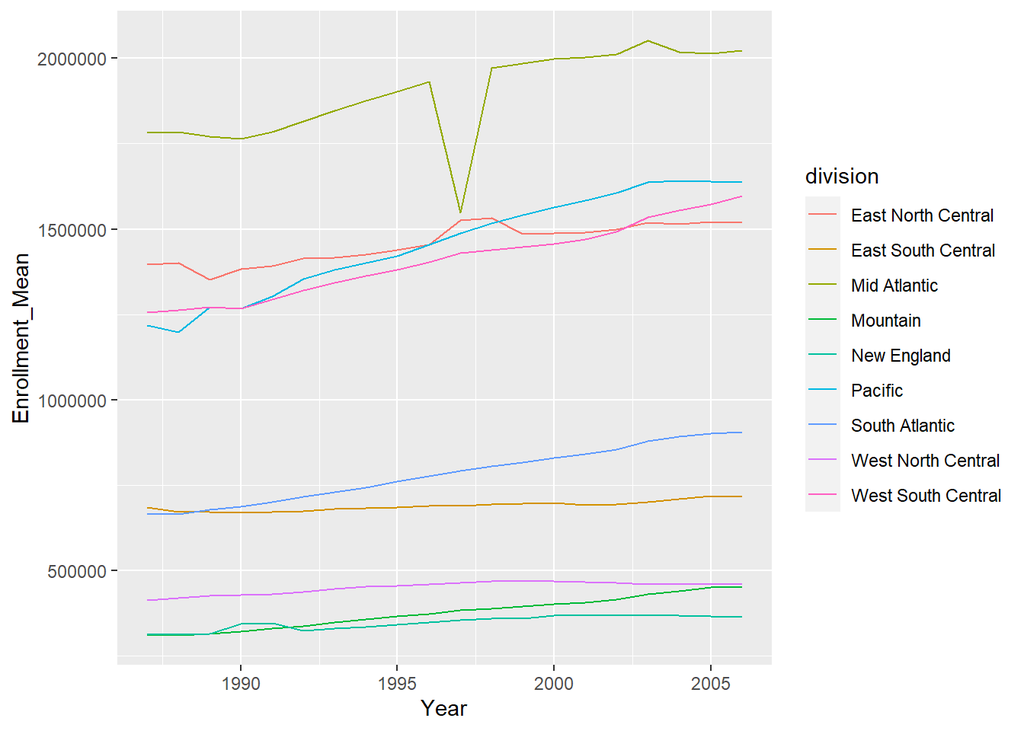

```r
plot(stateDF_1_2, var_name = "US_total_enrollment")
```

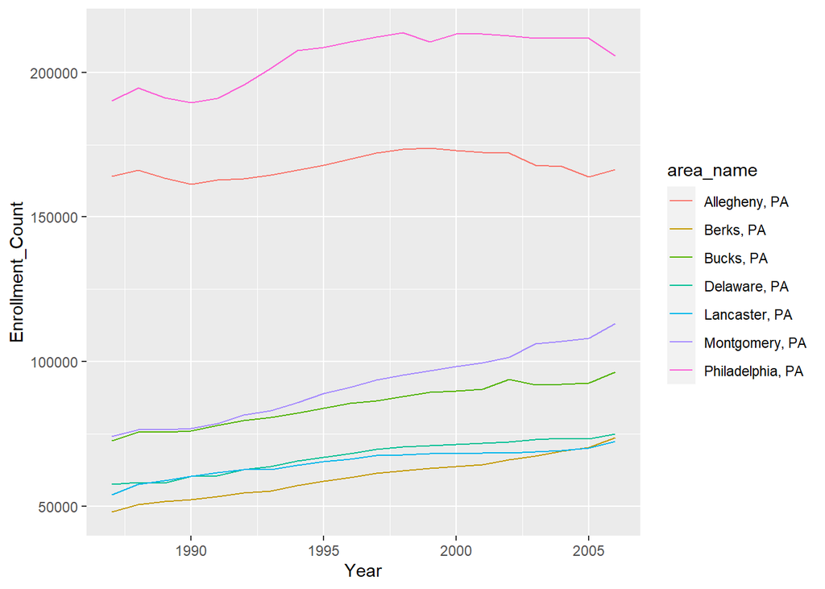

```r
plot(countyDF_1_2, var_name = "US_total_enrollment", stateVar = "PA", topBottomVar = "top", numberOfEntries = 7)
```

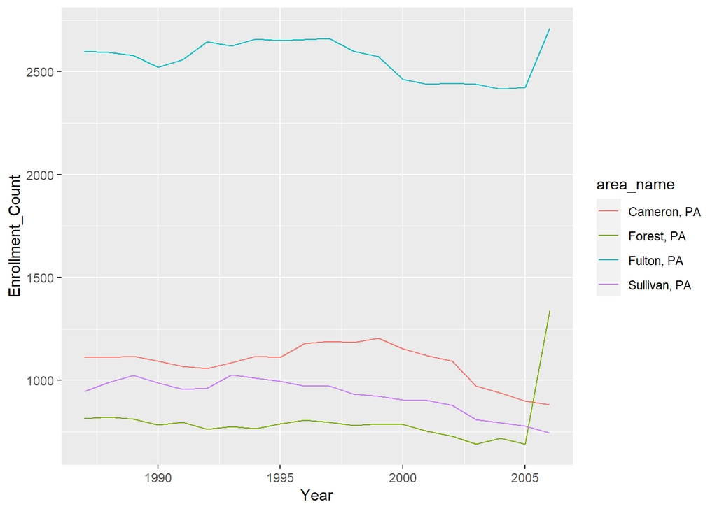

```r
plot(countyDF_1_2, var_name = "US_total_enrollment", stateVar = "PA", topBottomVar = "bottom", numberOfEntries = 4)
```

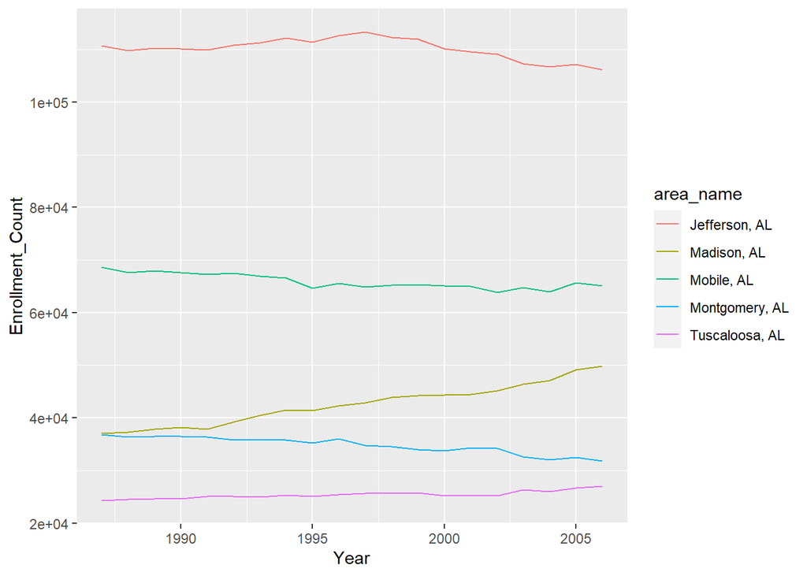

```r
plot(countyDF_1_2)
```

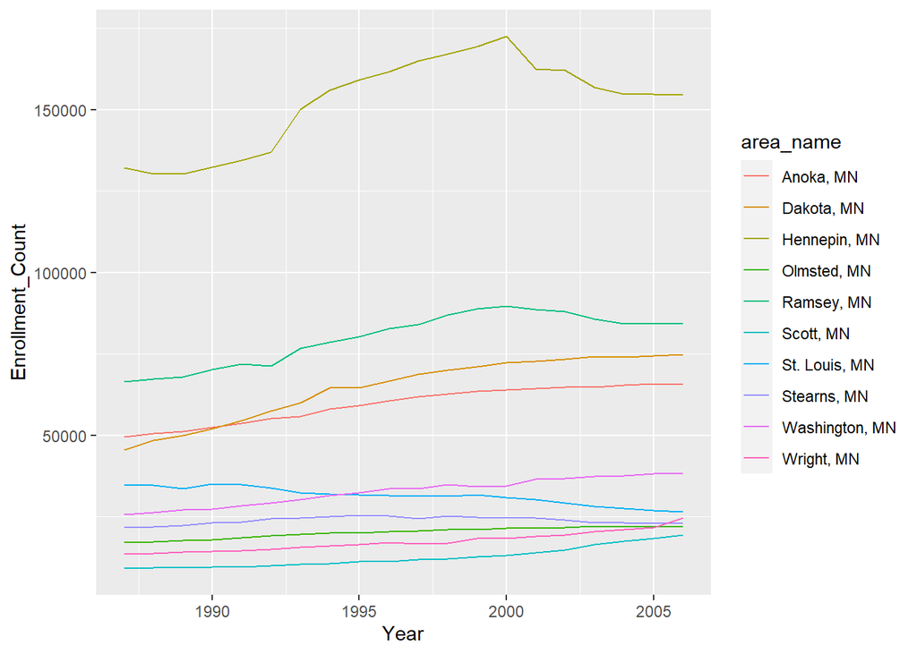

```r
plot(countyDF_1_2, var_name = "US_total_enrollment", stateVar = "MN", topBottomVar = "top", numberOfEntries = 10)
```

## Part-2

The below chunk of code will read and process the data from 4 csv files using my_Wrapper_function() and will combine all the 4 tibbles using combineFunction.

```r
thirdDF <- my_Wrapper_function("https://www4.stat.ncsu.edu/~online/datasets/PST01a.csv", colName = "US_total_enrollment")
fourthDF <- my_Wrapper_function("https://www4.stat.ncsu.edu/~online/datasets/PST01b.csv", colName = "US_total_enrollment")
fifthDF <- my_Wrapper_function("https://www4.stat.ncsu.edu/~online/datasets/PST01c.csv", colName = "US_total_enrollment")
SixthDF <- my_Wrapper_function("https://www4.stat.ncsu.edu/~online/datasets/PST01d.csv", colName = "US_total_enrollment")

combineDF_3_4 <- combineFunction(thirdDF,fourthDF)
combineDF_5_6 <- combineFunction(fifthDF,SixthDF)
combineFinal <- combineFunction(combineDF_3_4,combineDF_5_6)
countyDF <- combineFinal[[1]]
stateDF <- combineFinal[[2]]

combineFinal
```

```
## [[1]]
## # A tibble: 125,800 × 7
##    area_name   STCOU item_ID    US_total_enrollment  year measurement state
##    <chr>       <chr> <chr>                    <dbl> <dbl> <chr>       <chr>
##  1 Autauga, AL 01001 PST015171D               25508  1971 PST0151     AL
##  2 Autauga, AL 01001 PST015172D               27166  1972 PST0151     AL
##  3 Autauga, AL 01001 PST015173D               28463  1973 PST0151     AL
##  4 Autauga, AL 01001 PST015174D               29266  1974 PST0151     AL
##  5 Autauga, AL 01001 PST015175D               29718  1975 PST0151     AL
##  6 Autauga, AL 01001 PST015176D               29896  1976 PST0151     AL
##  7 Autauga, AL 01001 PST015177D               30462  1977 PST0151     AL
##  8 Autauga, AL 01001 PST015178D               30882  1978 PST0151     AL
##  9 Autauga, AL 01001 PST015179D               32055  1979 PST0151     AL
## 10 Autauga, AL 01001 PST025181D               31985  1981 PST0251     AL
## # … with 125,790 more rows
##
## [[2]]
## # A tibble: 2,120 × 7
##    area_name     STCOU item_ID    US_total_enrollment  year measurement division
##    <chr>         <chr> <chr>                    <dbl> <dbl> <chr>       <chr>
##  1 UNITED STATES 00000 PST015171D           206827028  1971 PST0151     ERROR
##  2 UNITED STATES 00000 PST015172D           209283904  1972 PST0151     ERROR
##  3 UNITED STATES 00000 PST015173D           211357490  1973 PST0151     ERROR
##  4 UNITED STATES 00000 PST015174D           213341552  1974 PST0151     ERROR
##  5 UNITED STATES 00000 PST015175D           215465246  1975 PST0151     ERROR
##  6 UNITED STATES 00000 PST015176D           217562728  1976 PST0151     ERROR
##  7 UNITED STATES 00000 PST015177D           219759860  1977 PST0151     ERROR
##  8 UNITED STATES 00000 PST015178D           222095080  1978 PST0151     ERROR
##  9 UNITED STATES 00000 PST015179D           224567234  1979 PST0151     ERROR
## 10 UNITED STATES 00000 PST025181D           229466391  1981 PST0251     ERROR
## # … with 2,110 more rows
```

The below chunk of code will plot state data frame and plot county data frame with given conditions for the state of CT, NC and MN.It generates plots for enrollment value against year and mean values of the enrollment, which will be helpful for the further analysis.

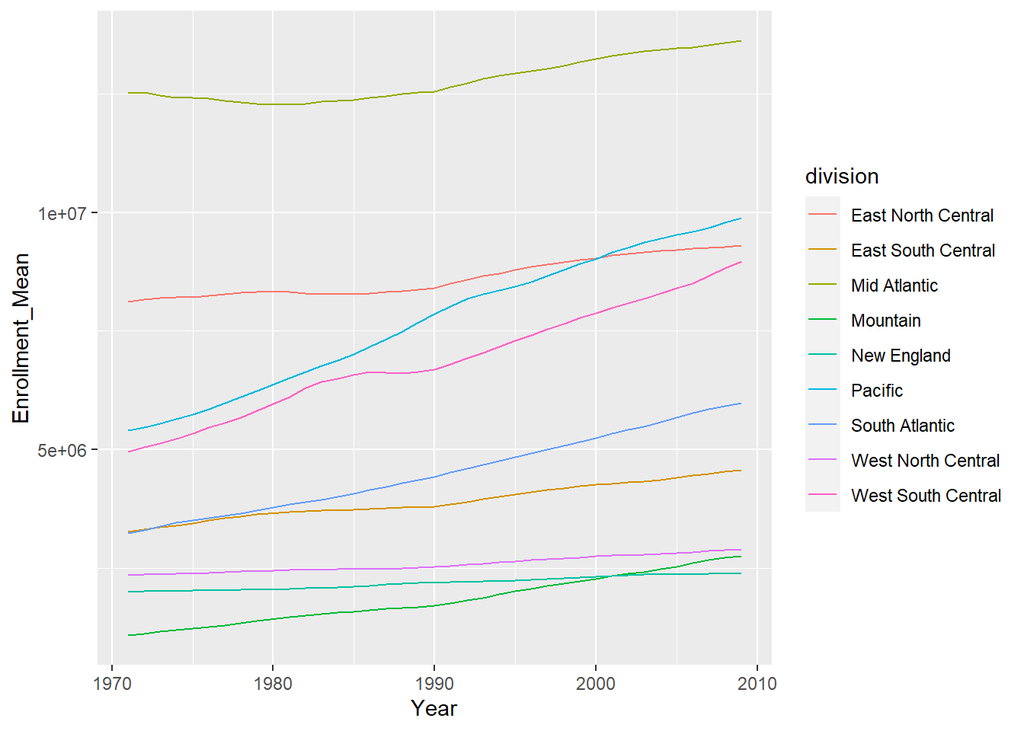

```r
plot(stateDF)
```

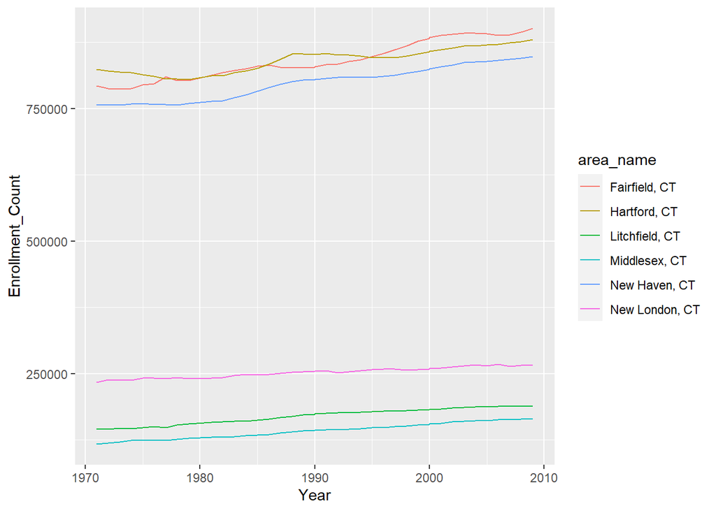

```r
plot(countyDF, stateVar="CT",topBottomVar="top",numberOfEntries=6)
```

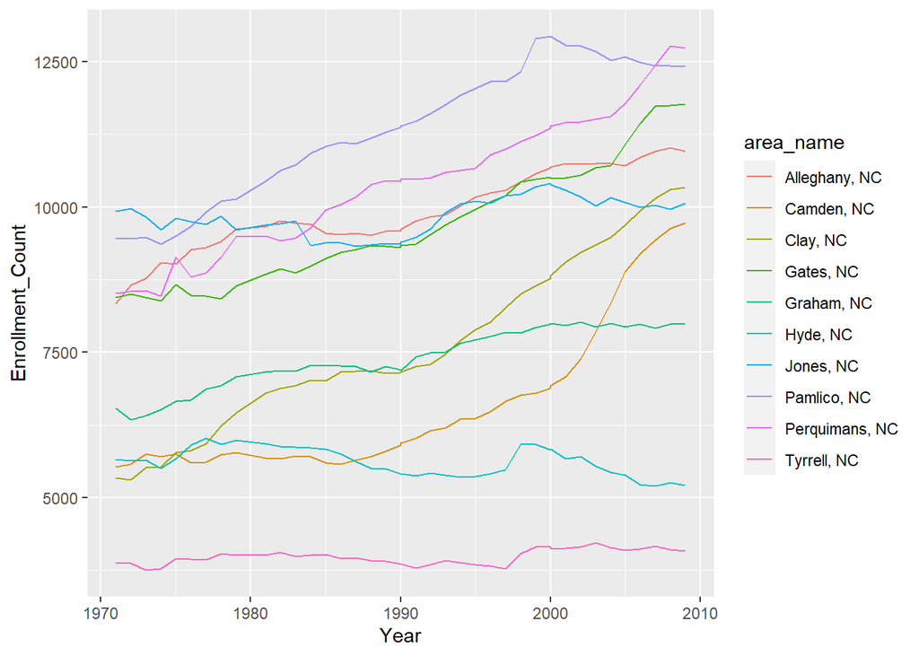

```r
plot(countyDF, stateVar="NC",topBottomVar="bottom",numberOfEntries=10)
```

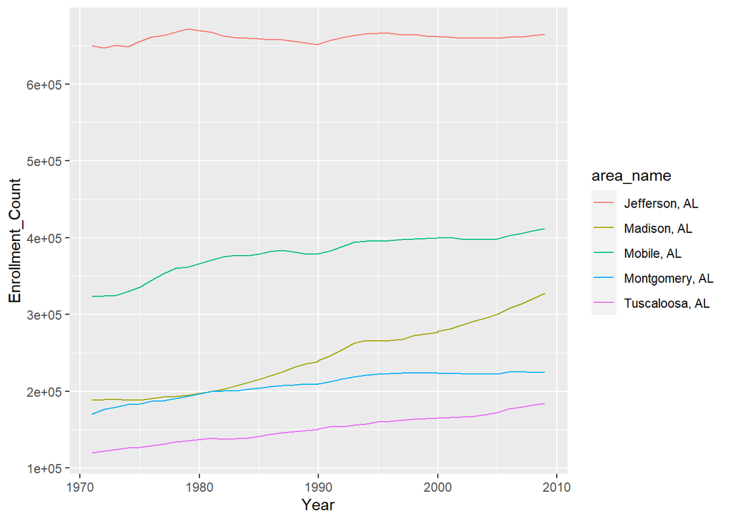

```r
plot(countyDF)
```

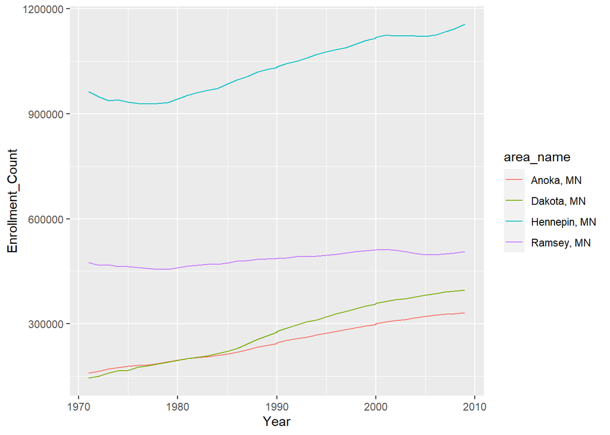

```r
plot(countyDF, stateVar="MN",topBottomVar="top",numberOfEntries=4)
```